# Has other (living) family members (e.g. parents, siblings, in-laws, etc.)

#### 2.1.6.4 Validation

### 2.1.7 Wave 7

#### 2.1.7.1 Study-specific variable description

The study-specific variable elected to be harmonised is:

- Name: `scfam`
- Label: `Whether the respondent has any other immediate family`
- Categories:
  - `1 = Yes`
  - `2 = No`
- Missings:
  - `-1 = Item not applicable`
  - `-2 = Schedule not applicable`
  - `-8 = Don't know`
  - `-9 = Not answered`
- Name: `DiNFA`
- Label: `Is your natural father still alive?`
- Categories:
  - `1 = Yes`
  - `2 = No`
- Missings:
  - `-9 = Refusal`
  - `-8 = Don't know`
  - `-2 = Schedule not applicable`
  - `-1 = Not applicable`
- Name: `DiNMA`
- Label: `Is your natural mother still alive?`
- Categories:
  - `1 = Yes`
  - `2 = No`
- Missings:
  - `-9 = Refusal`
  - `-8 = Don't know`
  - `-2 = Schedule not applicable`
  - `-1 = Not applicable`
- Name: `DiSib`
- Label: `Number of living brothers/sisters`
- Missings:
  - `-9 = Refusal`
  - `-8 = Don't know`
  - `-2 = Schedule not applicable`
  - `-1 = Not applicable`
- Description:

| Sample size | Missing values |
| --- | --- |
| 9666 | 1516 |

Category

|  | 1 | 2 |
| --- | --- | --- |
| Frequency | 7566.00 | 584.00 |
| Percentage | 78.27 | 6.04 |

Type of missing

|  | -9 | -8 | -2 | -1 | NA |
| --- | --- | --- | --- | --- | --- |
| Frequency | 47.00 | 0 | 1469.0 | 0 | 0 |
| Percentage | 0.49 | 0 | 15.2 | 0 | 0 |

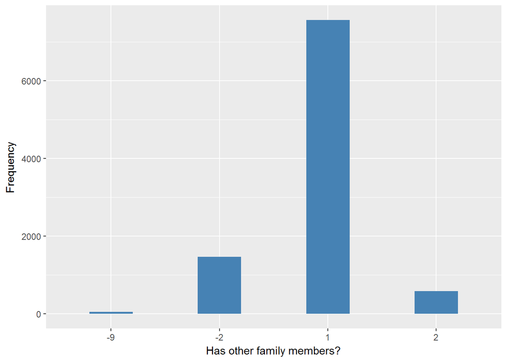

| Sample size | Missing values |
| --- | --- |
| 9666 | 7249 |

Category

|  | 1 | 2 |
| --- | --- | --- |
| Frequency | 1851.00 | 566.00 |
| Percentage | 19.15 | 5.86 |

Type of missing

|  | -9 | -8 | -2 | -1 | NA |
| --- | --- | --- | --- | --- | --- |
| Frequency | 0 | 33.00 | 0 | 7216.00 | 0 |
| Percentage | 0 | 0.34 | 0 | 74.65 | 0 |

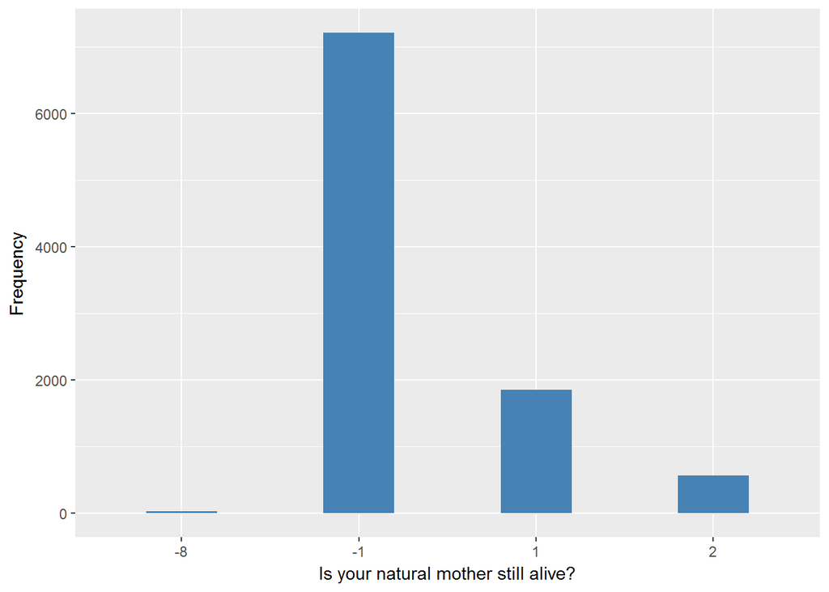

| Sample size | Missing values |
| --- | --- |
| 9666 | 8198 |

Category

|  | 1 | 2 |
| --- | --- | --- |
| Frequency | 917.00 | 551.0 |
| Percentage | 9.49 | 5.7 |

Type of missing

|  | -9 | -8 | -2 | -1 | NA |
| --- | --- | --- | --- | --- | --- |
| Frequency | 0 | 72.00 | 0 | 8126.00 | 0 |
| Percentage | 0 | 0.74 | 0 | 84.07 | 0 |

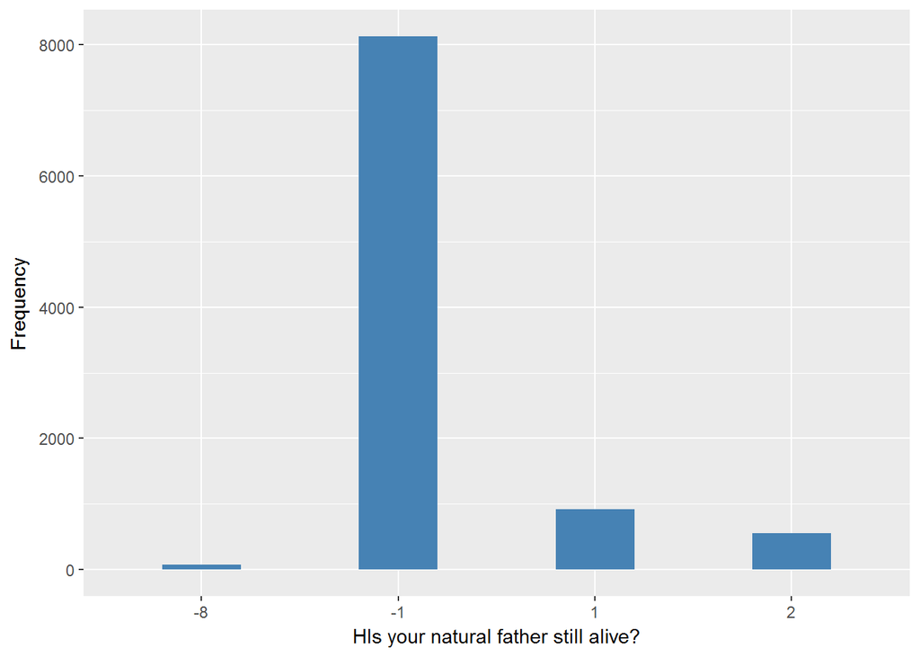

| Sample size | Missing values |
| --- | --- |
| 9666 | 21 |

Values

|  | No-missings | -9 | -8 | -1 | NA |
| --- | --- | --- | --- | --- | --- |
| Frequency | 9645.00 | 0 | 8.00 | 13.00 | 0 |
| Percentage | 99.78 | 0 | 0.08 | 0.13 | 0 |

Summary

| Min. | 1st Qu. | Median | Mean | 3rd Qu. | Max. |
| --- | --- | --- | --- | --- | --- |
| 0 | 1 | 1 | 1.842 | 3 | 16 |

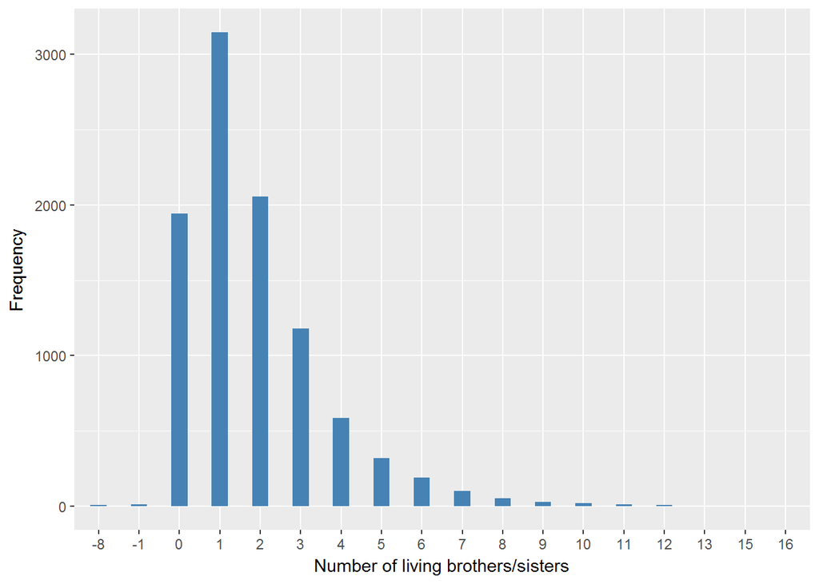

#### 2.1.7.2 Harmonisation algorithm

To recode the harmonize variable from the study-specific variable it has to be recoded as follows:

- `if any eqauls 1 or DiSib>0 then 1`
- `if all are equal 2 and DiSib=0 then 0`
- `-1 or -2 into 996`
- `-8 into 998`
- `-9 into 997, but -9 for scfam into 995`
- `NA into 999`

**R script:**

```r
ELSA_ds_w7 <- tibble(id = ELSA_w7_oth_fam$id)

ELSA_w7_oth_fam$scfam <- car::recode(as.vector(ELSA_w7_oth_fam$scfam), "NA='-999'")
ELSA_w7_oth_fam$DiNFA <- car::recode(as.vector(ELSA_w7_oth_fam$DiNFA), "NA='-999'")
ELSA_w7_oth_fam$DiNMA <- car::recode(as.vector(ELSA_w7_oth_fam$DiNMA), "NA='-999'")
ELSA_w7_oth_fam$DiSib <- car::recode(as.vector(ELSA_w7_oth_fam$DiSib), "NA='-999'")

ELSA_ds_w7$oth_fam <- c(NA)
for (i in 1:dim(ELSA_w7_oth_fam)[1]) {
    if (ELSA_w7_oth_fam$scfam[i] == 1 | ELSA_w7_oth_fam$DiNFA[i] == 1 | ELSA_w7_oth_fam$DiNMA[i] ==
        1 | ELSA_w7_oth_fam$DiSib[i] > 0) {
        ELSA_ds_w7$oth_fam[i] = 1
    } else if (ELSA_w7_oth_fam$scfam[i] == 2 & ELSA_w7_oth_fam$DiNFA[i] %in% c(2,
        -1) & ELSA_w7_oth_fam$DiNMA[i] %in% c(2, -1) & ELSA_w7_oth_fam$DiSib[i] ==
        0) {
        ELSA_ds_w7$oth_fam[i] = 0
    } else if (ELSA_w7_oth_fam$scfam[i] == -8 | ELSA_w7_oth_fam$DiNFA[i] == -8 |
        ELSA_w7_oth_fam$DiNMA[i] == -8 | ELSA_w7_oth_fam$DiSib[i] == -8) {
        ELSA_ds_w7$oth_fam[i] = 998
    } else if (ELSA_w7_oth_fam$scfam[i] == -2 | ELSA_w7_oth_fam$DiNFA[i] == -2 |
        ELSA_w7_oth_fam$DiNMA[i] == -2 | ELSA_w7_oth_fam$DiSib[i] == -2) {
        ELSA_ds_w7$oth_fam[i] = 996
    } else if (ELSA_w7_oth_fam$DiNFA[i] == -9 | ELSA_w7_oth_fam$DiNMA[i] == -9 |
        ELSA_w7_oth_fam$DiSib[i] == -9) {
        ELSA_ds_w7$oth_fam[i] = 997
    } else if (ELSA_w7_oth_fam$scfam[i] == -9) {
        ELSA_ds_w7$oth_fam[i] = 995
    } else if (ELSA_w7_oth_fam$scfam[i] == -1 | ELSA_w7_oth_fam$DiNFA[i] == -1 |
        ELSA_w7_oth_fam$DiNMA[i] == -1 | ELSA_w7_oth_fam$DiSib[i] == -1) {
        ELSA_ds_w7$oth_fam[i] = 996
    }
}

ELSA_ds_w7$oth_fam <- car::recode(as.vector(ELSA_ds_w7$oth_fam), "NA='999'")
ELSA_ds_w7$oth_fam <- labelled(ELSA_ds_w7$oth_fam, labels = c(No = 0, Yes = 1,
    Missing = 999, `Do not know` = 998, Refuse = 997, `Not applicable` = 996,
    `Don't answer` = 995, `Not attempt/not done/not yet recorded` = 994, `Disable to measure` = 993,
    Impute = 992, `CAPI/interviewer error` = 991))
```

#### 2.1.7.3 Statistical description of the new harmonised variable

| Sample size | Missing values |
| --- | --- |
| 9666 | 313 |

Category

|  | 0 | 1 |
| --- | --- | --- |
| Frequency | 462.00 | 8891.00 |
| Percentage | 4.78 | 91.98 |

Type of missing

|  | 991 | 992 | 993 | 994 | 995 | 996 | 997 | 998 | 999 | NA |
| --- | --- | --- | --- | --- | --- | --- | --- | --- | --- | --- |
| Frequency | 0 | 0 | 0 | 0 | 13.00 | 281.00 | 0 | 19.0 | 0 | 0 |
| Percentage | 0 | 0 | 0 | 0 | 0.13 | 2.91 | 0 | 0.2 | 0 | 0 |

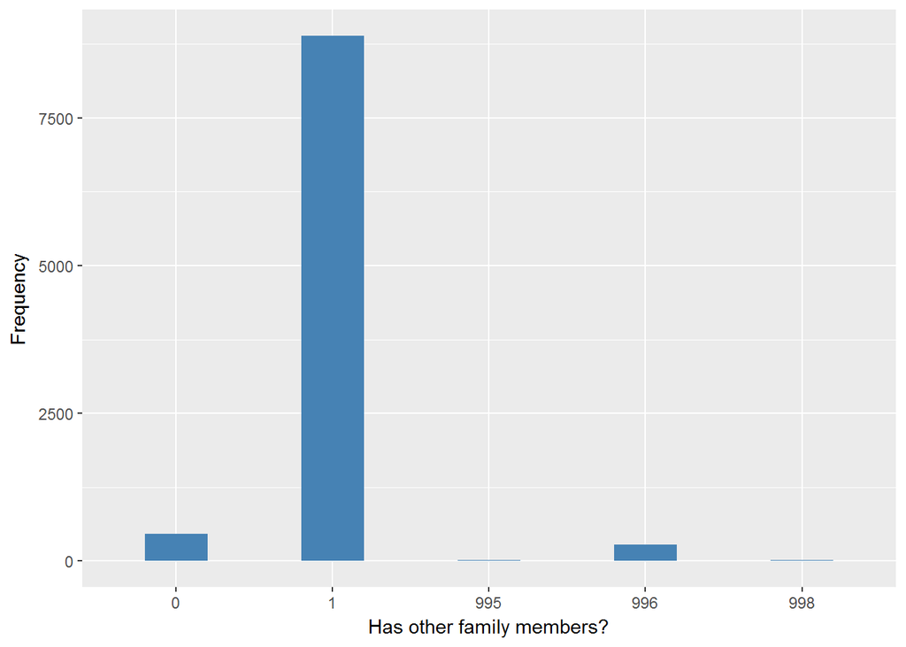

#### 2.1.7.4 Validation

# 3 Quality estimation